# Risk Factor Analysis

## Outcome Variable

**Outcome Variable:** haz

## Predictor Variables

**Intervention Variable:** predfeed3

**Adjustment Set:**

- arm
- sex
- month
- brthmon
- W_mage
- meducyrs
- feducyrs
- hhwealth_quart
- hfoodsec
- W_mhtcm
- W_mwtkg
- W_mbmi
- vagbrth
- W_gagebrth
- W_birthwt
- W_birthlen
- W_nrooms
- W_nchldlt5
- W_parity
- impfloor
- impsan
- safeh20
- delta_W_mage
- delta_meducyrs
- delta_feducyrs
- delta_hhwealth_quart
- delta_hfoodsec
- delta_W_mhtcm
- delta_W_mwtkg
- delta_W_mbmi
- delta_vagbrth
- delta_W_gagebrth
- delta_W_birthwt
- delta_W_birthlen
- delta_W_nrooms
- delta_W_nchldlt5
- delta_W_parity
- delta_impfloor
- delta_impsan
- delta_safeh20

## Stratifying Variables

The analysis was stratified on these variable(s):

- agecat
- studyid
- country

## Data Summary

| agecat | studyid | country | predfeed3 | n_cell | n | outcome_variable |
| --- | --- | --- | --- | --- | --- | --- |
| Birth | EE | PAKISTAN | 1 | 35 | 35 | haz |
| Birth | EE | PAKISTAN | 0 | 0 | 35 | haz |
| Birth | GMS-Nepal | NEPAL | 1 | 380 | 458 | haz |
| Birth | GMS-Nepal | NEPAL | 0 | 78 | 458 | haz |
| Birth | JiVitA-3 | BANGLADESH | 1 | 12017 | 13276 | haz |
| Birth | JiVitA-3 | BANGLADESH | 0 | 1259 | 13276 | haz |
| Birth | JiVitA-4 | BANGLADESH | 1 | 105 | 116 | haz |
| Birth | JiVitA-4 | BANGLADESH | 0 | 11 | 116 | haz |
| Birth | MAL-ED | BANGLADESH | 1 | 176 | 215 | haz |
| Birth | MAL-ED | BANGLADESH | 0 | 39 | 215 | haz |
| Birth | MAL-ED | BRAZIL | 1 | 24 | 57 | haz |
| Birth | MAL-ED | BRAZIL | 0 | 33 | 57 | haz |
| Birth | MAL-ED | INDIA | 1 | 29 | 41 | haz |
| Birth | MAL-ED | INDIA | 0 | 12 | 41 | haz |
| Birth | MAL-ED | NEPAL | 1 | 14 | 26 | haz |
| Birth | MAL-ED | NEPAL | 0 | 12 | 26 | haz |
| Birth | MAL-ED | PERU | 1 | 150 | 223 | haz |
| Birth | MAL-ED | PERU | 0 | 73 | 223 | haz |
| Birth | MAL-ED | SOUTH AFRICA | 1 | 33 | 100 | haz |
| Birth | MAL-ED | SOUTH AFRICA | 0 | 67 | 100 | haz |
| Birth | MAL-ED | TANZANIA, UNITED REPUBLIC OF | 1 | 26 | 102 | haz |
| Birth | MAL-ED | TANZANIA, UNITED REPUBLIC OF | 0 | 76 | 102 | haz |
| 6 months | EE | PAKISTAN | 1 | 39 | 39 | haz |
| 6 months | EE | PAKISTAN | 0 | 0 | 39 | haz |
| 6 months | GMS-Nepal | NEPAL | 1 | 367 | 441 | haz |
| 6 months | GMS-Nepal | NEPAL | 0 | 74 | 441 | haz |
| 6 months | JiVitA-3 | BANGLADESH | 1 | 8516 | 9328 | haz |
| 6 months | JiVitA-3 | BANGLADESH | 0 | 812 | 9328 | haz |
| 6 months | JiVitA-4 | BANGLADESH | 1 | 76 | 88 | haz |
| 6 months | JiVitA-4 | BANGLADESH | 0 | 12 | 88 | haz |
| 6 months | MAL-ED | BANGLADESH | 1 | 191 | 233 | haz |
| 6 months | MAL-ED | BANGLADESH | 0 | 42 | 233 | haz |
| 6 months | MAL-ED | BRAZIL | 1 | 93 | 187 | haz |
| 6 months | MAL-ED | BRAZIL | 0 | 94 | 187 | haz |
| 6 months | MAL-ED | INDIA | 1 | 147 | 210 | haz |
| 6 months | MAL-ED | INDIA | 0 | 63 | 210 | haz |
| 6 months | MAL-ED | NEPAL | 1 | 113 | 227 | haz |
| 6 months | MAL-ED | NEPAL | 0 | 114 | 227 | haz |
| 6 months | MAL-ED | PERU | 1 | 176 | 270 | haz |
| 6 months | MAL-ED | PERU | 0 | 94 | 270 | haz |
| 6 months | MAL-ED | SOUTH AFRICA | 1 | 63 | 244 | haz |
| 6 months | MAL-ED | SOUTH AFRICA | 0 | 181 | 244 | haz |
| 6 months | MAL-ED | TANZANIA, UNITED REPUBLIC OF | 1 | 64 | 212 | haz |
| 6 months | MAL-ED | TANZANIA, UNITED REPUBLIC OF | 0 | 148 | 212 | haz |
| 24 months | EE | PAKISTAN | 1 | 20 | 20 | haz |
| 24 months | EE | PAKISTAN | 0 | 0 | 20 | haz |
| 24 months | GMS-Nepal | NEPAL | 1 | 322 | 384 | haz |
| 24 months | GMS-Nepal | NEPAL | 0 | 62 | 384 | haz |
| 24 months | JiVitA-3 | BANGLADESH | 1 | 4434 | 4852 | haz |
| 24 months | JiVitA-3 | BANGLADESH | 0 | 418 | 4852 | haz |
| 24 months | JiVitA-4 | BANGLADESH | 1 | 136 | 151 | haz |
| 24 months | JiVitA-4 | BANGLADESH | 0 | 15 | 151 | haz |
| 24 months | MAL-ED | BANGLADESH | 1 | 168 | 205 | haz |
| 24 months | MAL-ED | BANGLADESH | 0 | 37 | 205 | haz |
| 24 months | MAL-ED | BRAZIL | 1 | 79 | 152 | haz |
| 24 months | MAL-ED | BRAZIL | 0 | 73 | 152 | haz |
| 24 months | MAL-ED | INDIA | 1 | 139 | 202 | haz |
| 24 months | MAL-ED | INDIA | 0 | 63 | 202 | haz |
| 24 months | MAL-ED | NEPAL | 1 | 110 | 220 | haz |
| 24 months | MAL-ED | NEPAL | 0 | 110 | 220 | haz |
| 24 months | MAL-ED | PERU | 1 | 131 | 198 | haz |
| 24 months | MAL-ED | PERU | 0 | 67 | 198 | haz |
| 24 months | MAL-ED | SOUTH AFRICA | 1 | 60 | 228 | haz |
| 24 months | MAL-ED | SOUTH AFRICA | 0 | 168 | 228 | haz |
| 24 months | MAL-ED | TANZANIA, UNITED REPUBLIC OF | 1 | 54 | 184 | haz |
| 24 months | MAL-ED | TANZANIA, UNITED REPUBLIC OF | 0 | 130 | 184 | haz |

The following strata were considered:

- agecat: 24 months, studyid: EE, country: PAKISTAN
- agecat: 24 months, studyid: GMS-Nepal, country: NEPAL
- agecat: 24 months, studyid: JiVitA-3, country: BANGLADESH
- agecat: 24 months, studyid: JiVitA-4, country: BANGLADESH
- agecat: 24 months, studyid: MAL-ED, country: BANGLADESH
- agecat: 24 months, studyid: MAL-ED, country: BRAZIL
- agecat: 24 months, studyid: MAL-ED, country: INDIA
- agecat: 24 months, studyid: MAL-ED, country: NEPAL
- agecat: 24 months, studyid: MAL-ED, country: PERU
- agecat: 24 months, studyid: MAL-ED, country: SOUTH AFRICA
- agecat: 24 months, studyid: MAL-ED, country: TANZANIA, UNITED REPUBLIC OF
- agecat: 6 months, studyid: EE, country: PAKISTAN
- agecat: 6 months, studyid: GMS-Nepal, country: NEPAL
- agecat: 6 months, studyid: JiVitA-3, country: BANGLADESH
- agecat: 6 months, studyid: JiVitA-4, country: BANGLADESH
- agecat: 6 months, studyid: MAL-ED, country: BANGLADESH
- agecat: 6 months, studyid: MAL-ED, country: BRAZIL
- agecat: 6 months, studyid: MAL-ED, country: INDIA
- agecat: 6 months, studyid: MAL-ED, country: NEPAL
- agecat: 6 months, studyid: MAL-ED, country: PERU
- agecat: 6 months, studyid: MAL-ED, country: SOUTH AFRICA
- agecat: 6 months, studyid: MAL-ED, country: TANZANIA, UNITED REPUBLIC OF
- agecat: Birth, studyid: EE, country: PAKISTAN
- agecat: Birth, studyid: GMS-Nepal, country: NEPAL
- agecat: Birth, studyid: JiVitA-3, country: BANGLADESH
- agecat: Birth, studyid: JiVitA-4, country: BANGLADESH
- agecat: Birth, studyid: MAL-ED, country: BANGLADESH
- agecat: Birth, studyid: MAL-ED, country: BRAZIL
- agecat: Birth, studyid: MAL-ED, country: INDIA
- agecat: Birth, studyid: MAL-ED, country: NEPAL
- agecat: Birth, studyid: MAL-ED, country: PERU
- agecat: Birth, studyid: MAL-ED, country: SOUTH AFRICA
- agecat: Birth, studyid: MAL-ED, country: TANZANIA, UNITED REPUBLIC OF

### Dropped Strata

Some strata were dropped due to rare outcomes:

- agecat: Birth, studyid: EE, country: PAKISTAN
- agecat: 6 months, studyid: EE, country: PAKISTAN
- agecat: 24 months, studyid: EE, country: PAKISTAN

## Methods Detail

We’re interested in the causal parameters $E[Y_a]$ for all values of $a \in \mathcal{A}$. These parameters represent the mean outcome if, possibly contrary to fact, we intervened to set all units to have $A=a$. Under the randomization and positivity assumptions, these are identified by the statistical parameters $\psi_a=E_W[E_{Y|A,W}(Y|A=a,W)]$. In addition, we’re interested in the mean of $Y$, $E[Y]$ under no intervention (the observed mean). We will estimate these parameters by using SuperLearner to fit the relevant likelihood factors – $E_{Y|A,W}(Y|A=a,W)$ and $p(A=a|W)$, and then updating our likelihood fit using a joint TMLE.

For unadjusted analyses ($W=\{\}$), initial likelihoods were estimated using Lrnr_glm to estimate the simple $E(Y|A)$ and Lrnr_mean to estimate $p(A)$. For adjusted analyses, a small library containing Lrnr_glmnet, Lrnr_xgboost, and Lrnr_mean was used.

Having estimated these parameters, we will then use the delta method to estimate relative risks and attributable risks relative to a prespecified baseline level of $A$.

# Results Detail

## Results Plots

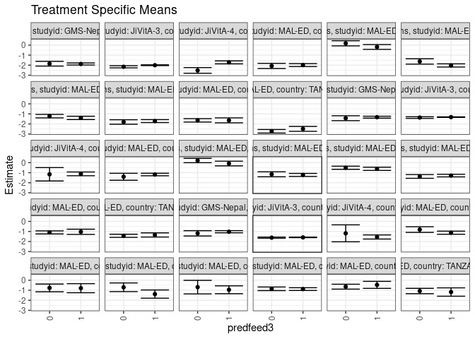

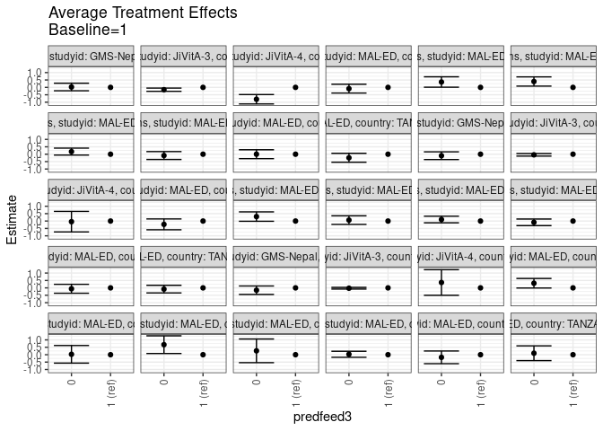

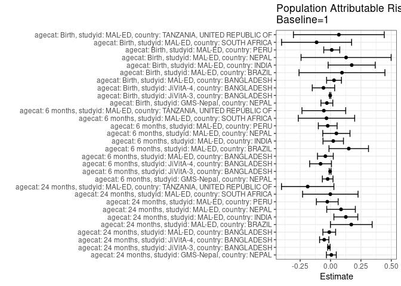

## Results Table

### Parameter: TSM

| agecat | studyid | country | intervention_level | baseline_level | estimate | ci_lower | ci_upper |
| --- | --- | --- | --- | --- | --- | --- | --- |
| Birth | GMS-Nepal | NEPAL | 1 | NA | -1.0253426 | -1.1325187 | -0.9181665 |
| Birth | GMS-Nepal | NEPAL | 0 | NA | -1.1848816 | -1.4494998 | -0.9202634 |
| Birth | JiVitA-3 | BANGLADESH | 1 | NA | -1.5901981 | -1.6138574 | -1.5665388 |
| Birth | JiVitA-3 | BANGLADESH | 0 | NA | -1.6141232 | -1.6693778 | -1.5588686 |
| Birth | JiVitA-4 | BANGLADESH | 1 | NA | -1.5491389 | -1.7539614 | -1.3443164 |
| Birth | JiVitA-4 | BANGLADESH | 0 | NA | -1.1857061 | -2.0297545 | -0.3416577 |
| Birth | MAL-ED | BANGLADESH | 1 | NA | -1.1235564 | -1.2777734 | -0.9693394 |
| Birth | MAL-ED | BANGLADESH | 0 | NA | -0.8113640 | -1.0936232 | -0.5291048 |
| Birth | MAL-ED | BRAZIL | 1 | NA | -0.7937283 | -1.2455597 | -0.3418969 |
| Birth | MAL-ED | BRAZIL | 0 | NA | -0.7671430 | -1.1515461 | -0.3827399 |
| Birth | MAL-ED | INDIA | 1 | NA | -1.3817552 | -1.7928815 | -0.9706289 |
| Birth | MAL-ED | INDIA | 0 | NA | -0.7043710 | -1.1364871 | -0.2722549 |
| Birth | MAL-ED | NEPAL | 1 | NA | -0.9516074 | -1.3446451 | -0.5585697 |
| Birth | MAL-ED | NEPAL | 0 | NA | -0.6896398 | -1.3666578 | -0.0126217 |
| Birth | MAL-ED | PERU | 1 | NA | -0.8853043 | -1.0230614 | -0.7475472 |
| Birth | MAL-ED | PERU | 0 | NA | -0.8555903 | -1.0351622 | -0.6760184 |
| Birth | MAL-ED | SOUTH AFRICA | 1 | NA | -0.4648421 | -0.8133793 | -0.1163049 |
| Birth | MAL-ED | SOUTH AFRICA | 0 | NA | -0.6431128 | -0.8881501 | -0.3980755 |
| Birth | MAL-ED | TANZANIA, UNITED REPUBLIC OF | 1 | NA | -1.1769708 | -1.5936384 | -0.7603031 |
| Birth | MAL-ED | TANZANIA, UNITED REPUBLIC OF | 0 | NA | -1.0770471 | -1.3441061 | -0.8099881 |
| 6 months | GMS-Nepal | NEPAL | 1 | NA | -1.3263942 | -1.4213331 | -1.2314553 |
| 6 months | GMS-Nepal | NEPAL | 0 | NA | -1.4276362 | -1.6708525 | -1.1844198 |
| 6 months | JiVitA-3 | BANGLADESH | 1 | NA | -1.3204192 | -1.3496273 | -1.2912111 |
| 6 months | JiVitA-3 | BANGLADESH | 0 | NA | -1.3621852 | -1.4473828 | -1.2769876 |
| 6 months | JiVitA-4 | BANGLADESH | 1 | NA | -1.1172513 | -1.3055607 | -0.9289419 |
| 6 months | JiVitA-4 | BANGLADESH | 0 | NA | -1.1597670 | -1.8265805 | -0.4929535 |
| 6 months | MAL-ED | BANGLADESH | 1 | NA | -1.1817896 | -1.3075687 | -1.0560105 |
| 6 months | MAL-ED | BANGLADESH | 0 | NA | -1.4062789 | -1.7511096 | -1.0614483 |
| 6 months | MAL-ED | BRAZIL | 1 | NA | -0.0889034 | -0.3220849 | 0.1442782 |
| 6 months | MAL-ED | BRAZIL | 0 | NA | 0.2112438 | -0.0049415 | 0.4274291 |
| 6 months | MAL-ED | INDIA | 1 | NA | -1.2223501 | -1.3701850 | -1.0745153 |
| 6 months | MAL-ED | INDIA | 0 | NA | -1.1589841 | -1.4084698 | -0.9094985 |
| 6 months | MAL-ED | NEPAL | 1 | NA | -0.6114439 | -0.7735704 | -0.4493174 |
| 6 months | MAL-ED | NEPAL | 0 | NA | -0.5078287 | -0.6645862 | -0.3510713 |
| 6 months | MAL-ED | PERU | 1 | NA | -1.2875144 | -1.4158694 | -1.1591594 |
| 6 months | MAL-ED | PERU | 0 | NA | -1.3746109 | -1.5617697 | -1.1874522 |
| 6 months | MAL-ED | SOUTH AFRICA | 1 | NA | -1.0328611 | -1.2917449 | -0.7739774 |
| 6 months | MAL-ED | SOUTH AFRICA | 0 | NA | -1.0943052 | -1.2477357 | -0.9408748 |
| 6 months | MAL-ED | TANZANIA, UNITED REPUBLIC OF | 1 | NA | -1.3478959 | -1.5551031 | -1.1406888 |
| 6 months | MAL-ED | TANZANIA, UNITED REPUBLIC OF | 0 | NA | -1.4319412 | -1.5879739 | -1.2759085 |
| 24 months | GMS-Nepal | NEPAL | 1 | NA | -1.8818496 | -1.9835974 | -1.7801019 |
| 24 months | GMS-Nepal | NEPAL | 0 | NA | -1.8562966 | -2.0920080 | -1.6205852 |
| 24 months | JiVitA-3 | BANGLADESH | 1 | NA | -2.0051889 | -2.0429984 | -1.9673794 |
| 24 months | JiVitA-3 | BANGLADESH | 0 | NA | -2.1618416 | -2.2683404 | -2.0553427 |
| 24 months | JiVitA-4 | BANGLADESH | 1 | NA | -1.7206648 | -1.8687279 | -1.5726017 |
| 24 months | JiVitA-4 | BANGLADESH | 0 | NA | -2.5230086 | -2.8041726 | -2.2418446 |
| 24 months | MAL-ED | BANGLADESH | 1 | NA | -1.9910029 | -2.1383395 | -1.8436664 |
| 24 months | MAL-ED | BANGLADESH | 0 | NA | -2.0761340 | -2.3333348 | -1.8189333 |
| 24 months | MAL-ED | BRAZIL | 1 | NA | -0.1871419 | -0.4257103 | 0.0514264 |
| 24 months | MAL-ED | BRAZIL | 0 | NA | 0.1754253 | -0.0814278 | 0.4322784 |
| 24 months | MAL-ED | INDIA | 1 | NA | -2.0252955 | -2.1840103 | -1.8665808 |
| 24 months | MAL-ED | INDIA | 0 | NA | -1.6285539 | -1.8953799 | -1.3617280 |
| 24 months | MAL-ED | NEPAL | 1 | NA | -1.3973096 | -1.5611711 | -1.2334480 |
| 24 months | MAL-ED | NEPAL | 0 | NA | -1.2220688 | -1.3940944 | -1.0500431 |
| 24 months | MAL-ED | PERU | 1 | NA | -1.7143543 | -1.8606821 | -1.5680265 |
| 24 months | MAL-ED | PERU | 0 | NA | -1.8047022 | -2.0253403 | -1.5840642 |
| 24 months | MAL-ED | SOUTH AFRICA | 1 | NA | -1.6405434 | -1.8871305 | -1.3939564 |
| 24 months | MAL-ED | SOUTH AFRICA | 0 | NA | -1.6404703 | -1.8110805 | -1.4698601 |
| 24 months | MAL-ED | TANZANIA, UNITED REPUBLIC OF | 1 | NA | -2.4886753 | -2.7315782 | -2.2457725 |
| 24 months | MAL-ED | TANZANIA, UNITED REPUBLIC OF | 0 | NA | -2.7294636 | -2.9066408 | -2.5522864 |

### Parameter: E(Y)

| agecat | studyid | country | intervention_level | baseline_level | estimate | ci_lower | ci_upper |
| --- | --- | --- | --- | --- | --- | --- | --- |
| Birth | GMS-Nepal | NEPAL | NA | NA | -1.0555240 | -1.1550843 | -0.9559638 |
| Birth | JiVitA-3 | BANGLADESH | NA | NA | -1.5928457 | -1.6158667 | -1.5698248 |
| Birth | JiVitA-4 | BANGLADESH | NA | NA | -1.6073276 | -1.8105798 | -1.4040753 |
| Birth | MAL-ED | BANGLADESH | NA | NA | -1.0949767 | -1.2319917 | -0.9579618 |
| Birth | MAL-ED | BRAZIL | NA | NA | -0.6996491 | -0.9856018 | -0.4136965 |
| Birth | MAL-ED | INDIA | NA | NA | -1.2075610 | -1.5261540 | -0.8889679 |
| Birth | MAL-ED | NEPAL | NA | NA | -0.8234615 | -1.1896049 | -0.4573182 |
| Birth | MAL-ED | PERU | NA | NA | -0.8753812 | -0.9932108 | -0.7575515 |
| Birth | MAL-ED | SOUTH AFRICA | NA | NA | -0.5797000 | -0.7788298 | -0.3805702 |
| Birth | MAL-ED | TANZANIA, UNITED REPUBLIC OF | NA | NA | -1.1086275 | -1.3310338 | -0.8862211 |
| 6 months | GMS-Nepal | NEPAL | NA | NA | -1.3499849 | -1.4387386 | -1.2612312 |
| 6 months | JiVitA-3 | BANGLADESH | NA | NA | -1.3240051 | -1.3526414 | -1.2953689 |
| 6 months | JiVitA-4 | BANGLADESH | NA | NA | -1.1994318 | -1.3808291 | -1.0180345 |
| 6 months | MAL-ED | BANGLADESH | NA | NA | -1.2242918 | -1.3439424 | -1.1046413 |
| 6 months | MAL-ED | BRAZIL | NA | NA | 0.0609091 | -0.0944768 | 0.2162950 |
| 6 months | MAL-ED | INDIA | NA | NA | -1.2002381 | -1.3274929 | -1.0729833 |
| 6 months | MAL-ED | NEPAL | NA | NA | -0.5634068 | -0.6769687 | -0.4498449 |
| 6 months | MAL-ED | PERU | NA | NA | -1.3108735 | -1.4182407 | -1.2035062 |
| 6 months | MAL-ED | SOUTH AFRICA | NA | NA | -1.0662227 | -1.1965862 | -0.9358591 |
| 6 months | MAL-ED | TANZANIA, UNITED REPUBLIC OF | NA | NA | -1.4030503 | -1.5292443 | -1.2768563 |
| 24 months | GMS-Nepal | NEPAL | NA | NA | -1.8752995 | -1.9688053 | -1.7817937 |
| 24 months | JiVitA-3 | BANGLADESH | NA | NA | -2.0187325 | -2.0554682 | -1.9819968 |
| 24 months | JiVitA-4 | BANGLADESH | NA | NA | -1.7726490 | -1.9111913 | -1.6341067 |
| 24 months | MAL-ED | BANGLADESH | NA | NA | -2.0016585 | -2.1303297 | -1.8729874 |
| 24 months | MAL-ED | BRAZIL | NA | NA | -0.0162939 | -0.1929098 | 0.1603221 |
| 24 months | MAL-ED | INDIA | NA | NA | -1.8994059 | -2.0346781 | -1.7641337 |
| 24 months | MAL-ED | NEPAL | NA | NA | -1.3109318 | -1.4313748 | -1.1904888 |
| 24 months | MAL-ED | PERU | NA | NA | -1.7412963 | -1.8630698 | -1.6195228 |
| 24 months | MAL-ED | SOUTH AFRICA | NA | NA | -1.6424525 | -1.7808926 | -1.5040124 |
| 24 months | MAL-ED | TANZANIA, UNITED REPUBLIC OF | NA | NA | -2.6768207 | -2.8213178 | -2.5323235 |

### Parameter: ATE

| agecat | studyid | country | intervention_level | baseline_level | estimate | ci_lower | ci_upper |
| --- | --- | --- | --- | --- | --- | --- | --- |
| Birth | GMS-Nepal | NEPAL | 1 | 1 | 0.0000000 | 0.0000000 | 0.0000000 |
| Birth | GMS-Nepal | NEPAL | 0 | 1 | -0.1595390 | -0.4451912 | 0.1261133 |
| Birth | JiVitA-3 | BANGLADESH | 1 | 1 | 0.0000000 | 0.0000000 | 0.0000000 |
| Birth | JiVitA-3 | BANGLADESH | 0 | 1 | -0.0239251 | -0.0796249 | 0.0317747 |
| Birth | JiVitA-4 | BANGLADESH | 1 | 1 | 0.0000000 | 0.0000000 | 0.0000000 |
| Birth | JiVitA-4 | BANGLADESH | 0 | 1 | 0.3634328 | -0.5010973 | 1.2279629 |
| Birth | MAL-ED | BANGLADESH | 1 | 1 | 0.0000000 | 0.0000000 | 0.0000000 |
| Birth | MAL-ED | BANGLADESH | 0 | 1 | 0.3121924 | -0.0105836 | 0.6349684 |
| Birth | MAL-ED | BRAZIL | 1 | 1 | 0.0000000 | 0.0000000 | 0.0000000 |
| Birth | MAL-ED | BRAZIL | 0 | 1 | 0.0265853 | -0.5681215 | 0.6212921 |
| Birth | MAL-ED | INDIA | 1 | 1 | 0.0000000 | 0.0000000 | 0.0000000 |
| Birth | MAL-ED | INDIA | 0 | 1 | 0.6773842 | 0.0795369 | 1.2752314 |
| Birth | MAL-ED | NEPAL | 1 | 1 | 0.0000000 | 0.0000000 | 0.0000000 |
| Birth | MAL-ED | NEPAL | 0 | 1 | 0.2619676 | -0.5372267 | 1.0611620 |
| Birth | MAL-ED | PERU | 1 | 1 | 0.0000000 | 0.0000000 | 0.0000000 |
| Birth | MAL-ED | PERU | 0 | 1 | 0.0297140 | -0.1733573 | 0.2327853 |
| Birth | MAL-ED | SOUTH AFRICA | 1 | 1 | 0.0000000 | 0.0000000 | 0.0000000 |
| Birth | MAL-ED | SOUTH AFRICA | 0 | 1 | -0.1782707 | -0.6070070 | 0.2504656 |
| Birth | MAL-ED | TANZANIA, UNITED REPUBLIC OF | 1 | 1 | 0.0000000 | 0.0000000 | 0.0000000 |
| Birth | MAL-ED | TANZANIA, UNITED REPUBLIC OF | 0 | 1 | 0.0999236 | -0.3981582 | 0.5980054 |
| 6 months | GMS-Nepal | NEPAL | 1 | 1 | 0.0000000 | 0.0000000 | 0.0000000 |
| 6 months | GMS-Nepal | NEPAL | 0 | 1 | -0.1012420 | -0.3626637 | 0.1601798 |
| 6 months | JiVitA-3 | BANGLADESH | 1 | 1 | 0.0000000 | 0.0000000 | 0.0000000 |
| 6 months | JiVitA-3 | BANGLADESH | 0 | 1 | -0.0417660 | -0.1279684 | 0.0444363 |
| 6 months | JiVitA-4 | BANGLADESH | 1 | 1 | 0.0000000 | 0.0000000 | 0.0000000 |
| 6 months | JiVitA-4 | BANGLADESH | 0 | 1 | -0.0425157 | -0.7371467 | 0.6521153 |
| 6 months | MAL-ED | BANGLADESH | 1 | 1 | 0.0000000 | 0.0000000 | 0.0000000 |
| 6 months | MAL-ED | BANGLADESH | 0 | 1 | -0.2244893 | -0.5917633 | 0.1427847 |
| 6 months | MAL-ED | BRAZIL | 1 | 1 | 0.0000000 | 0.0000000 | 0.0000000 |
| 6 months | MAL-ED | BRAZIL | 0 | 1 | 0.3001471 | -0.0172212 | 0.6175155 |
| 6 months | MAL-ED | INDIA | 1 | 1 | 0.0000000 | 0.0000000 | 0.0000000 |
| 6 months | MAL-ED | INDIA | 0 | 1 | 0.0633660 | -0.2271230 | 0.3538550 |
| 6 months | MAL-ED | NEPAL | 1 | 1 | 0.0000000 | 0.0000000 | 0.0000000 |
| 6 months | MAL-ED | NEPAL | 0 | 1 | 0.1036151 | -0.1197769 | 0.3270072 |
| 6 months | MAL-ED | PERU | 1 | 1 | 0.0000000 | 0.0000000 | 0.0000000 |
| 6 months | MAL-ED | PERU | 0 | 1 | -0.0870965 | -0.3096556 | 0.1354626 |
| 6 months | MAL-ED | SOUTH AFRICA | 1 | 1 | 0.0000000 | 0.0000000 | 0.0000000 |
| 6 months | MAL-ED | SOUTH AFRICA | 0 | 1 | -0.0614441 | -0.3632609 | 0.2403727 |
| 6 months | MAL-ED | TANZANIA, UNITED REPUBLIC OF | 1 | 1 | 0.0000000 | 0.0000000 | 0.0000000 |
| 6 months | MAL-ED | TANZANIA, UNITED REPUBLIC OF | 0 | 1 | -0.0840453 | -0.3415220 | 0.1734315 |
| 24 months | GMS-Nepal | NEPAL | 1 | 1 | 0.0000000 | 0.0000000 | 0.0000000 |
| 24 months | GMS-Nepal | NEPAL | 0 | 1 | 0.0255530 | -0.2298178 | 0.2809239 |
| 24 months | JiVitA-3 | BANGLADESH | 1 | 1 | 0.0000000 | 0.0000000 | 0.0000000 |
| 24 months | JiVitA-3 | BANGLADESH | 0 | 1 | -0.1566527 | -0.2663558 | -0.0469495 |
| 24 months | JiVitA-4 | BANGLADESH | 1 | 1 | 0.0000000 | 0.0000000 | 0.0000000 |
| 24 months | JiVitA-4 | BANGLADESH | 0 | 1 | -0.8023438 | -1.1200638 | -0.4846238 |
| 24 months | MAL-ED | BANGLADESH | 1 | 1 | 0.0000000 | 0.0000000 | 0.0000000 |
| 24 months | MAL-ED | BANGLADESH | 0 | 1 | -0.0851311 | -0.3826086 | 0.2123465 |
| 24 months | MAL-ED | BRAZIL | 1 | 1 | 0.0000000 | 0.0000000 | 0.0000000 |
| 24 months | MAL-ED | BRAZIL | 0 | 1 | 0.3625672 | 0.0112466 | 0.7138878 |
| 24 months | MAL-ED | INDIA | 1 | 1 | 0.0000000 | 0.0000000 | 0.0000000 |
| 24 months | MAL-ED | INDIA | 0 | 1 | 0.3967416 | 0.0853125 | 0.7081707 |
| 24 months | MAL-ED | NEPAL | 1 | 1 | 0.0000000 | 0.0000000 | 0.0000000 |
| 24 months | MAL-ED | NEPAL | 0 | 1 | 0.1752408 | -0.0590006 | 0.4094822 |
| 24 months | MAL-ED | PERU | 1 | 1 | 0.0000000 | 0.0000000 | 0.0000000 |
| 24 months | MAL-ED | PERU | 0 | 1 | -0.0903479 | -0.3555947 | 0.1748988 |
| 24 months | MAL-ED | SOUTH AFRICA | 1 | 1 | 0.0000000 | 0.0000000 | 0.0000000 |
| 24 months | MAL-ED | SOUTH AFRICA | 0 | 1 | 0.0000731 | -0.2998717 | 0.3000178 |
| 24 months | MAL-ED | TANZANIA, UNITED REPUBLIC OF | 1 | 1 | 0.0000000 | 0.0000000 | 0.0000000 |
| 24 months | MAL-ED | TANZANIA, UNITED REPUBLIC OF | 0 | 1 | -0.2407883 | -0.5422327 | 0.0606561 |

### Parameter: PAR

| agecat | studyid | country | intervention_level | baseline_level | estimate | ci_lower | ci_upper |
| --- | --- | --- | --- | --- | --- | --- | --- |
| Birth | GMS-Nepal | NEPAL | 1 | NA | -0.0301814 | -0.0789978 | 0.0186350 |
| Birth | JiVitA-3 | BANGLADESH | 1 | NA | -0.0026477 | -0.0079148 | 0.0026195 |
| Birth | JiVitA-4 | BANGLADESH | 1 | NA | -0.0581887 | -0.1503819 | 0.0340045 |
| Birth | MAL-ED | BANGLADESH | 1 | NA | 0.0285796 | -0.0324275 | 0.0895868 |
| Birth | MAL-ED | BRAZIL | 1 | NA | 0.0940792 | -0.2594733 | 0.4476317 |
| Birth | MAL-ED | INDIA | 1 | NA | 0.1741942 | -0.0197134 | 0.3681018 |
| Birth | MAL-ED | NEPAL | 1 | NA | 0.1281459 | -0.2426294 | 0.4989212 |
| Birth | MAL-ED | PERU | 1 | NA | 0.0099232 | -0.0559875 | 0.0758338 |
| Birth | MAL-ED | SOUTH AFRICA | 1 | NA | -0.1148579 | -0.4030658 | 0.1733500 |
| Birth | MAL-ED | TANZANIA, UNITED REPUBLIC OF | 1 | NA | 0.0683433 | -0.3054417 | 0.4421283 |
| 6 months | GMS-Nepal | NEPAL | 1 | NA | -0.0235907 | -0.0673695 | 0.0201882 |
| 6 months | JiVitA-3 | BANGLADESH | 1 | NA | -0.0035859 | -0.0110590 | 0.0038871 |
| 6 months | JiVitA-4 | BANGLADESH | 1 | NA | -0.0821805 | -0.1719049 | 0.0075439 |
| 6 months | MAL-ED | BANGLADESH | 1 | NA | -0.0425022 | -0.1075071 | 0.0225027 |
| 6 months | MAL-ED | BRAZIL | 1 | NA | 0.1498124 | -0.0127393 | 0.3123642 |
| 6 months | MAL-ED | INDIA | 1 | NA | 0.0221120 | -0.0621201 | 0.1063442 |
| 6 months | MAL-ED | NEPAL | 1 | NA | 0.0480371 | -0.0639932 | 0.1600674 |
| 6 months | MAL-ED | PERU | 1 | NA | -0.0233590 | -0.1005398 | 0.0538218 |
| 6 months | MAL-ED | SOUTH AFRICA | 1 | NA | -0.0333615 | -0.2653197 | 0.1985967 |
| 6 months | MAL-ED | TANZANIA, UNITED REPUBLIC OF | 1 | NA | -0.0551544 | -0.2352024 | 0.1248936 |
| 24 months | GMS-Nepal | NEPAL | 1 | NA | 0.0065502 | -0.0339741 | 0.0470744 |
| 24 months | JiVitA-3 | BANGLADESH | 1 | NA | -0.0135436 | -0.0230387 | -0.0040484 |
| 24 months | JiVitA-4 | BANGLADESH | 1 | NA | -0.0519842 | -0.0902100 | -0.0137585 |
| 24 months | MAL-ED | BANGLADESH | 1 | NA | -0.0106556 | -0.0631393 | 0.0418281 |
| 24 months | MAL-ED | BRAZIL | 1 | NA | 0.1708481 | -0.0008276 | 0.3425238 |
| 24 months | MAL-ED | INDIA | 1 | NA | 0.1258896 | 0.0274739 | 0.2243053 |
| 24 months | MAL-ED | NEPAL | 1 | NA | 0.0863777 | -0.0313407 | 0.2040962 |
| 24 months | MAL-ED | PERU | 1 | NA | -0.0269420 | -0.1165399 | 0.0626558 |
| 24 months | MAL-ED | SOUTH AFRICA | 1 | NA | -0.0019091 | -0.2301332 | 0.2263151 |
| 24 months | MAL-ED | TANZANIA, UNITED REPUBLIC OF | 1 | NA | -0.1881453 | -0.4038036 | 0.0275130 |